# **[Universidade Federal Rural de Pernambuco](http://ufrpe.br/)** **[Departamento de Matemática](http://www.dm.ufrpe.br/)** **[Disciplina: Cálculo M I](https://sites.google.com/site/ricardonunesmachadojr/disciplinas/c%C3%A1lculo-mi)** **[Prof. Ricardo Machado](https://sites.google.com/site/ricardonunesmachadojr/)**

## [Índice de Aulas](https://sagectu.com.br/calculo1.github.io/index.html) Aula 4

## Função Derivada Derivadas de Ordem Superior Notações para Derivada Regra da Cadeia

# Referências:

[figure not shown]

[figure not shown]

### Observação: Nota de aula produzida usando o software [SageMath](http://www.sagemath.org/), usando o notbook [Jupyter](https://jupyter.org/). Use o SageMathCell com vários exemplos em: sagectu.com.br/sagecell.html

## 1 - Função Derivada

## Seja $f(x)$ uma função. Considere o conjunto $A$, para os quais $f'(x)$ existe. A função $$ \begin{array}{ccc} f:A & \longrightarrow & \mathbb{R}\\ x & \longmapsto & f'(x) \end{array} $$ é chamada de função derivada, ou derivada de $f$, ou derivada de 1ª ordem de $f$, indicada por $f^{(1)}$.

## 2 - Derivadas de Ordem Superior

## A derivada de $f'$ é chamada de derivada de 2ª ordem de $f$ e é indicada por $f''$ ou por $f^{(2)}$. De modo análogo, define-se a derivada de ordem $n$ de $f$ e ela é indicada por $f^{(n)}$.

## Exercício 2.1. Seja $f(x) = 3x^3-6x+1$. Determine $f^{(1)}$, $f^{(2)}$ e $f^{(3)}$ e seus domínios.

```python
f = 3*x^3-6*x+1
diff(f)
```

```
9*x^2 - 6
```

```python
diff(f, x, 2)
```

```
18*x
```

```python
diff(f, x, 3)
```

```
18
```

## Exercício 2.2. Seja $$f(x) = \begin{cases} x^2, & x\leq 1 \\ 1, & x > 1 \end{cases}$$ a) Esboce o gráfico de $f$; b) Determine $f'$ e seu domínio; c) Esboce o gráfico de $f'$.

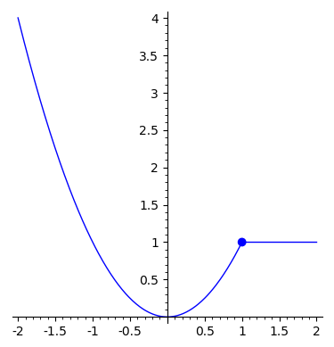

```python
p1 = plot(x^2, (-2, 1), figsize=[4,4])
c1 = circle((1,1), 0.05, fill=true)
p2 = plot(1, (1, 2), figsize=[4,4])
p1+c1+p2
```

## Como $f'(1)$ não existe, temos que calcular a derivada da função em $(-\infty, 1)$ e $(1, \infty)$.

```python
df1 = diff(x^2)
df2 = diff(1)
df1, df2
```

```
(2*x, 0)
```

## $$f'(x) = \begin{cases} 2x, & x< 1 \\ 0, & x > 1 \end{cases}$$ O domínio de $f'$ é $\mathbb{R}\setminus \{1\}$.

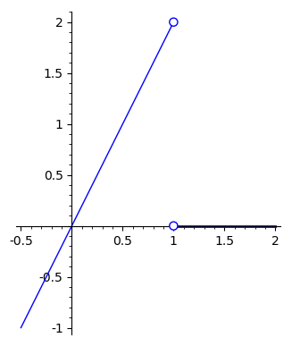

```python
p1 = plot(2*x, (-0.5, 1))
c1 = circle((1,2), 0.04,  fill=True, edgecolor='blue', facecolor='white')
p2 = plot(0, (1, 2), thickness=2)
c2 = circle((1,0), 0.04, fill=True, edgecolor='blue', facecolor='white')
p1+c1+p2+c2
```

## Exercício 2.3. Seja $$f(x) = x^2|x|$$ Esboce os gráficos de $f$, $f'$ e $f''$.

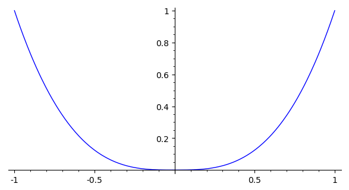

```python
f = x^2*abs(x)
plot(f, (-1, 1), aspect_ratio=1)
```

```python
x = var('x', domain=RR)
df1 = diff(f, x)
df1.full_simplify().show()
```

$$\newcommand{\Bold}[1]{\mathbf{#1}}3 \, x {\left| x \right|}$$

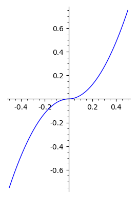

```python
plot(df1, (-0.5, 0.5), aspect_ratio=1)
```

```python
df2 = diff(f, x, 2)
df2.full_simplify().show()
```

$$\newcommand{\Bold}[1]{\mathbf{#1}}6 \, {\left| x \right|}$$

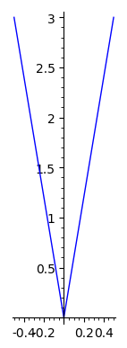

```python
plot(df2, (-0.5, 0.5), aspect_ratio=1)
```

## 3 - Notações para Derivada

## Notação de Leibniz Seja $y = f(x)$. $\displaystyle \frac{dy}{dx} = f'(x) = \lim_{\Delta x\rightarrow 0} \frac{f(x+\Delta x)-f(x)}{\Delta x}$. Fazendo $\Delta y = f(x+\Delta x)-f(x)$, temos $\displaystyle \frac{dy}{dx} = f'(x) = \lim_{\Delta x\rightarrow 0} \frac{\Delta y}{\Delta x}$.

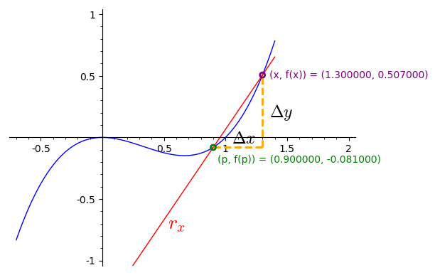

```python
p1 = plot_f_reta(x^3-x^2, 1.3, 0.9, (-0.7, 1.4), (-1, 1))
l1 = line(((0.9, -0.081),(1.3, -0.081)), color='orange', thickness=2, linestyle='--')
l2 = line(((1.3, -0.081), (1.3, 0.507)), color='orange', thickness=2, linestyle='--')
tx = text('$r_x$', (0.6, -0.7), color='red', fontsize=20)
dy = text('$\Delta y$', (1.45, 0.2), color='black', fontsize=17)
dx = text('$\Delta x$', (1.15, -0.01), color='black', fontsize=17)
(p1+l1+l2+tx+dy+dx)
```

## A notação $\displaystyle \frac{dy}{dx}\bigl\vert_{x=x_0} $ é usada para indicar $f'(x_0)$.

## Também usaremos a notação $\displaystyle \frac{df}{dx}$ para a função derivada de $y = f(x)$, ou seja, $\displaystyle \frac{df}{dx} = f'$.

## A derivada de $y = f(x)$, em $x$ será indicada por $\displaystyle \frac{df}{dx}(x)$.

## Exercício 3.1 Seja $y = 5x^3+x^2$. Usando a notação de Leibniz, calcule a derivada de $y$.

## R. E 3.1 $\displaystyle\frac{dy}{dx} = \frac{d}{dx}(5x^3+x^2) = (5x^3+x^2)' = 15x^2+2x.$

```python
f = 5*x^3+x^2
diff(f).show()
```

$$\newcommand{\Bold}[1]{\mathbf{#1}}15 \, x^{2} + 2 \, x$$

## Exercício 3.2 Calcule $\dfrac{ds}{dt}$ sendo $s = \dfrac{5t}{t^2+1}$.

```python
t = var('t')
s = (5*t)/(t^2+1)
diff(s, t).full_simplify().show()
```

$$\newcommand{\Bold}[1]{\mathbf{#1}}-\frac{5 \, {\left(t^{2} - 1\right)}}{t^{4} + 2 \, t^{2} + 1}$$

## > $\displaystyle (f\circ g)'(t_0) = \lim_{t\rightarrow t_0} \dfrac{f(g(t))-f(g(t_0))}{t-t_0} = $

## >$\hspace{2cm} =\displaystyle\lim_{t\rightarrow t_0} \dfrac{f(g(t))-f(g(t_0))}{g(t)-g(t_0)}\cdot \dfrac{g(t)-g(t_0)}{t-t_0} = $

## $\hspace{2cm} = \displaystyle\lim_{t\rightarrow t_0} \dfrac{f(g(t))-f(g(t_0))}{g(t)-g(t_0)}\cdot \lim_{t\rightarrow t_0}\dfrac{g(t)-g(t_0)}{t-t_0} = f'(g(t_0))\cdot g'(t_0)$.

## Exercício 4.1 Calcule a derivada a) $y = e^{3x}$ b) $y = sen(t^2)$

dica:

> a) faça $u = 3x$ e $y = e^u$.

> b) faça $x = t^2$ e $y = sen(x)$

```python
f = e^(3*x)
diff(f, x).show()
```

$$\newcommand{\Bold}[1]{\mathbf{#1}}3 \, e^{\left(3 \, x\right)}$$

```python
f = sin(t^2)
diff(f, t).show()
```

$$\newcommand{\Bold}[1]{\mathbf{#1}}2 \, t \cos\left(t^{2}\right)$$

## Exercício 4.2 Calcule $f'(x)$, sendo a) $f(x) = (3x^2+1)^3$ b) $f(x) = \cos(3x).$

```python
f = (3*x^2+1)^3
diff(f, x).show()
```

$$\newcommand{\Bold}[1]{\mathbf{#1}}18 \, {\left(3 \, x^{2} + 1\right)}^{2} x$$

```python
f = cos(3*x)
diff(f, x).show()
```

$$\newcommand{\Bold}[1]{\mathbf{#1}}-3 \, \sin\left(3 \, x\right)$$

## Exercício 4.3 Calcule $f'(x)$, sendo $f(x) = \ln(x^2+3)$.

```python
f = log(x^2+3)
diff(f, x).show()
```

$$\newcommand{\Bold}[1]{\mathbf{#1}}\frac{2 \, x}{x^{2} + 3}$$

## Exercício 4.4 Seja $f:\mathbb{R}\rightarrow \mathbb{R}$ uma função derivável e seja $g(x)=f(cos(x))$. Calcule $g'\left( \dfrac{\pi}{3}\right)$ supondo $f'\left( \dfrac{1}{2} \right)=4$.

## Exercício 4.5 Seja $f(x) = x^2e^{3x}$. Calcule a derivada.

```python
f = x^2*e^(3*x)
diff(f, x).full_simplify().show()
```

$$\newcommand{\Bold}[1]{\mathbf{#1}}{\left(3 \, x^{2} + 2 \, x\right)} e^{\left(3 \, x\right)}$$

## Exercício 4.6 Seja $y = xe^{-2x}$. Verifique que $$ \frac{d^2y}{dx^2} + 4 \frac{dy}{dx} +4y = 0$$

```python
y = x*e^(-2*x)
diff(y, x, 2) + 4* diff(y, x) + 4*y
```

```
0
```

## Exercício 4.7 Calcule $\displaystyle \frac{d^2y}{dx^2}$, sendo $y = \cos(5x)$.

```python
y = cos(5*x)
diff(y, x, 2).show()
```

$$\newcommand{\Bold}[1]{\mathbf{#1}}-25 \, \cos\left(5 \, x\right)$$

## Exercício 4.8 Calcule $\displaystyle \frac{dy}{dx}$. a)$\displaystyle y = \left( \frac{x+1}{x^2+1} \right)^4.$ b) $y = \sqrt[3]{x^2+3}$.

```python
y = ((x+1)/(x^2+1))^4
diff(y, x).simplify().show()
```

$$\newcommand{\Bold}[1]{\mathbf{#1}}-\frac{8 \, {\left(x + 1\right)}^{4} x}{{\left(x^{2} + 1\right)}^{5}} + \frac{4 \, {\left(x + 1\right)}^{3}}{{\left(x^{2} + 1\right)}^{4}}$$

```python
y = (x^2+3)^(1/3)
diff(y, x).simplify().show()
```

$$\newcommand{\Bold}[1]{\mathbf{#1}}\frac{2 \, x}{3 \, {\left(x^{2} + 3\right)}^{\frac{2}{3}}}$$

## Exercício 4.9 Calcule a derivada. a)$\displaystyle y = x^x$. b) $y = 3^x$.

```python
y = x^x
diff(y, x).show()
```

$$\newcommand{\Bold}[1]{\mathbf{#1}}x^{x} {\left(\log\left(x\right) + 1\right)}$$

```python
y = 3^x
diff(y, x).show()
```

$$\newcommand{\Bold}[1]{\mathbf{#1}}3^{x} \log\left(3\right)$$